# Lab 4

Kuzyshyn, Mishchenko

# Tasks 1 - 4

## Generating sample data

All of this is done according to the formula in the statement of the problem.

```r
n = 100
m = 50
k <- 1:(m + n)
id <- 56  # Team ID
a.data = sapply(k, function(x) (x * log(x^2 * id + pi))%%1)
x = qnorm(a.data[1:n])
y = qnorm(a.data[(n + 1):(n + m)])
```

## Task 1

As variance is unknown, it’s convenient to use the t-test here.

As we have one-sided alternative, the rejection region would be:

$C_\alpha = \{x \in R^{100} | t(x) \le t_{0.05}^{99}\}$

```r
# As std is unknown, let's estimate it firstly
S <- sd(x)
sample_mean <- mean(x)
student <- (sample_mean - 0)* sqrt(100) / S
t <- qt(0.05, df=99)

if (student <= t){
  print("The test concluded that the that the null hypothesis should be rejected at alpha = 0.05")
} else{
    print("The test concluded that the that the null hypothesis should not be rejected at alpha = 0.05")
}

t.test(x, mu = 0, alternative = "less")
```

[output not shown]

## Task 2

Here, we test for the strict equality of $\mu_1$ and $\mu_2$ with variances assumed known: $\sigma^2_1=\sigma^2_2=2$.

For this, we use the GLRT with test statistics $2log\textbf{L}_{x,y}(H_0, H_1)$ in comparison to $\chi^{(1)}_{1-\alpha}$, with test size equal to 0.05.

```r
alpha <- 0.05
var <- 2

chisq_statistic <- (m * n / (m + n)) * ((mean(x) - mean(y))^2 / var)
```

You can also transform the coefficient into a z-score by using its square root, at which point you can use the z-test of size 1 - alpha / 2.

```r
norm_statistic <- sqrt(chisq_statistic)
```

The p-value of these tests is identical, since they themselves are merely transformations of each other, and is exactly:

```r
pvalue <- 2 * pnorm(-norm_statistic)
```

## Task 3

Here, we test for $\sigma^2_1=1$ with $\mu_1=0$.

This is a two-sided chi-squared test with the statistics of $V=\sum^n_{k=1}(X_k-\mu)^2/\sigma^2_0$

```r
alpha <- 0.05
mu <- 0
var <- 1
chisq_statistic <- sum(((x - mu) ^ 2) / var)
```

The p-value is twice the smaller of the chi-squared c.d.f. at V(X) or 1 minus the same value.

```r
pvalue <- 2 * min(pchisq(chisq_statistic, df=1),  1 - pchisq(chisq_statistic, df=1))
```

## Task 4

### Problem 4

In this problem, both means and both variances are unknown, so, according to hint, we should use the f-test here.

Hence, our test statistics is $F = Var(x)/Var(y)$ and the rejection region would be:

$C_{\alpha} = \{x \in R^{n} | F > F_{0.05, 99, 49}\}$

```r
S_x = var(x)
S_y = var(y)
f_statistic <- S_x / S_y
f <- qf(alpha, 99, 49)

if (f_statistic > f){
  print("The test concluded that the that the null hypothesis should be rejected at alpha = 0.05")
} else{
    print("The test concluded that the that the null hypothesis should not be rejected at alpha = 0.05")
}


pf(f_statistic, 99, 49)
```

[output not shown]

### Problem 5

|  | X | sex | age | children | smoker | charges | bmi | region |
| --- | --- | --- | --- | --- | --- | --- | --- | --- |
| X | 1 |  |  |  |  |  |  |  |
| sex | -0.0037 | 1 |  |  |  |  |  |  |
| age | -0.031 | 0.021 | 1 |  |  |  |  |  |
| children | 0.025 | -0.017 | 0.042 | 1 |  |  |  |  |
| smoker | 0.0052 | -0.076 | -0.025 | 0.0077 | 1 |  |  |  |
| charges | -0.0034 | -0.057 | 0.3 | 0.068 | 0.79 | 1 |  |  |
| bmi | -0.036 | -0.046 | 0.11 | 0.013 | 0.0038 | 0.2 | 1 |  |
| region | -0.023 | -0.017 | -0.012 | -0.023 | 0.068 | 0.074 | 0.27 | 1 |

|  | X | sex | age | children | smoker | charges | bmi | region |
| --- | --- | --- | --- | --- | --- | --- | --- | --- |
| X | 0 |  |  |  |  |  |  |  |
| sex | 0.89 | 0 |  |  |  |  |  |  |
| age | 0.25 | 0.45 | 0 |  |  |  |  |  |
| children | 0.36 | 0.53 | 0.12 | 0 |  |  |  |  |
| smoker | 0.85 | 0.0053 | 0.36 | 0.78 | 0 |  |  |  |
| charges | 0.9 | 0.036 | 4.9e-29 | 0.013 | 8.3e-283 | 0 |  |  |
| bmi | 0.19 | 0.09 | 6.2e-05 | 0.64 | 0.89 | 2.5e-13 | 0 |  |
| region | 0.4 | 0.53 | 0.67 | 0.4 | 0.012 | 0.0068 | 8.7e-24 | 0 |

```
$sym
         X sex age children smoker charges bmi region
X        1
sex        1
age            1
children           1
smoker                      1
charges                     ,      1
bmi                                        1
region                                         1
attr(,"legend")
[1] 0 ‘ ’ 0.3 ‘.’ 0.6 ‘,’ 0.8 ‘+’ 0.9 ‘*’ 0.95 ‘B’ 1
```

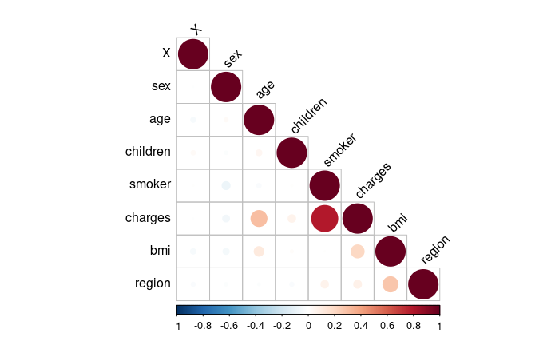

```r
dataframe <- read.csv("insurance.csv")

rquery.cormat(dataframe)
```

As we can see from the matrix above, the biggest correlation with charges are the following parameters: 1) Whether a person is smoker or not(correlation +0.79) 2) The age of a person(+0.3) The rest are almost uncorrelated, so we will not count them, in order to save computational power.

```r
multi.fit <- lm(charges ~ smoker + age, data=dataframe)
summary(multi.fit)
```

```
Call:
lm(formula = charges ~ smoker + age, data = dataframe)

Residuals:
     Min       1Q   Median       3Q      Max
-16088.1  -2046.8  -1336.4   -212.7  28760.0

Coefficients:
            Estimate Std. Error t value Pr(>|t|)
(Intercept) -2391.63     528.30  -4.527 6.52e-06 ***
smoker      23855.30     433.49  55.031  < 2e-16 ***
age           274.87      12.46  22.069  < 2e-16 ***
---
Signif. codes:  0 ‘***’ 0.001 ‘**’ 0.01 ‘*’ 0.05 ‘.’ 0.1 ‘ ’ 1

Residual standard error: 6397 on 1335 degrees of freedom
Multiple R-squared:  0.7214,    Adjusted R-squared:  0.721
F-statistic:  1728 on 2 and 1335 DF,  p-value: < 2.2e-16
```

1. $\hat{a}= -2391.63$(sum of all $\hat{a}_1, \hat{a}_2 ...$) $\hat{b}_1 = 23855.30$, $\hat{b_2} = 274.87$. Standard error is equal to 6397
2. As the p-value is much less than 0.01, we can reject the null hypothesis. Hence there is significant relationship between the charges, and age with smoker variables.
3. The determination coefficient $r^2$ is equal to 0.7214008. According to multiple articles that we have read, the R square of .70 is generally considered very good, so we can say that our linear model is adequate.

```r
predict(multi.fit, newdata=data_1, interval="prediction")
```

```
        fit       lwr      upr
1 -2391.626 -14983.13 10199.88
```

```r
predict(multi.fit, newdata=data_2, interval="prediction")
```

```
       fit      lwr      upr
1 480211.9 459216.9 501206.8
```

The confidence interval for x=20 is gigantic because smoker is a boolean variable that can not be 20)